# HW6 - DATA 609

Thomas Hill

November 14, 2021

```r
library(knitr)
library(class)
```

**Ex. 1** – Use a dataset such as the *PlantGrowth* in R to calculate three distance metrics and discuss the results.

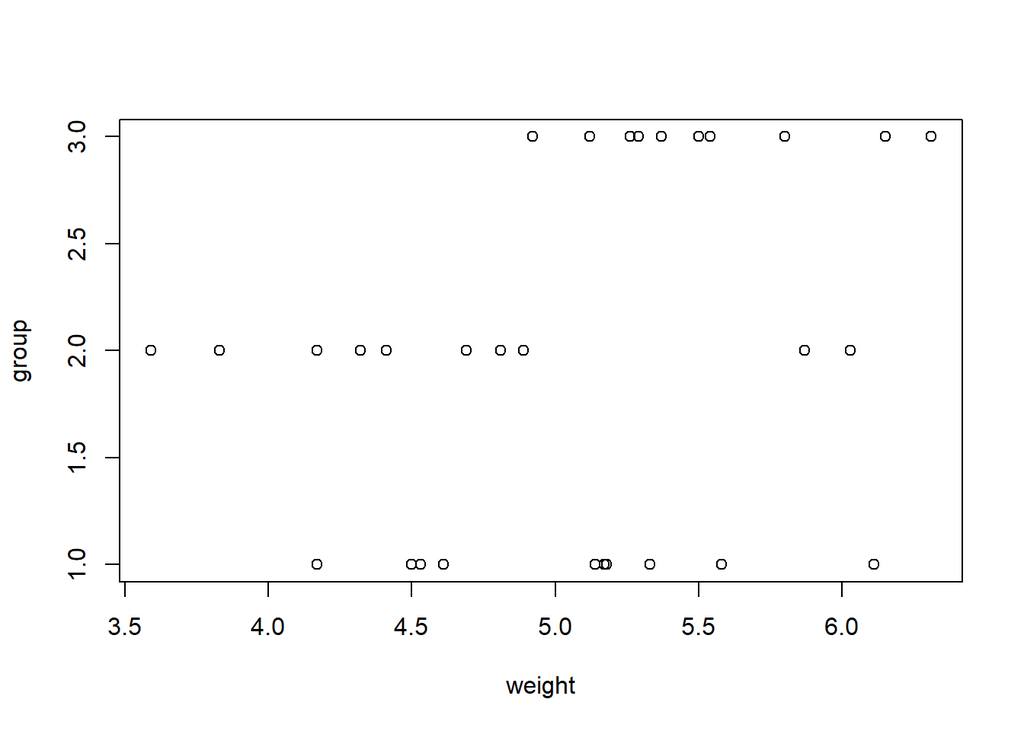

```r
pg <- PlantGrowth

plot(pg)
```

PlantGrowth is a dataframe comparing the yields of plants that had one of two treatments, or no treatment at all. Because these treatments only consider weight and another another dimension like treatment dose, I’ll start by looking at the distance between points ranked by size. Because of this, the Euclidean and Manhattan distances are the same.

```r
sum(abs(sort(pg[pg$group == 'trt1',][['weight']]) - sort(pg[pg$group == 'ctrl',][['weight']])))
```

```
## [1] 4.29
```

```r
sum(abs(sort(pg[pg$group == 'trt2',][['weight']]) - sort(pg[pg$group == 'ctrl',][['weight']])))
```

```
## [1] 4.94
```

Using this metric, treatment 1 appears slightly closer to the control.

Next, lets consider the distance of each treatment to its nearest control neighbor. I did this by subtracting each control value from a single treatment, found the absolute value of each difference, and located the minimum value of the vector. I did this for all 10 samples and summed the total distances as calculated by Euclidean distance.

```r
pg_ctrl <- pg[pg$group == 'ctrl',][['weight']]
pg_t1 <- pg[pg$group == 'trt1',][['weight']]
pg_t2 <- pg[pg$group == 'trt2',][['weight']]


sum(min(abs(pg_t1[1] - pg_ctrl)) + min(abs(pg_t1[2] - pg_ctrl)) + min(abs(pg_t1[3] - pg_ctrl)) + min(abs(pg_t1[4] - pg_ctrl)) + min(abs(pg_t1[5] - pg_ctrl)) + min(abs(pg_t1[6] - pg_ctrl)) + min(abs(pg_t1[7] - pg_ctrl)) + min(abs(pg_t1[8] - pg_ctrl)) + min(abs(pg_t1[9] - pg_ctrl)) + min(abs(pg_t1[10] - pg_ctrl)))
```

```
## [1] 2.01
```

```r
sum(min(abs(pg_t2[1] - pg_ctrl)) + min(abs(pg_t2[2] - pg_ctrl)) + min(abs(pg_t2[3] - pg_ctrl)) + min(abs(pg_t2[4] - pg_ctrl)) + min(abs(pg_t2[5] - pg_ctrl)) + min(abs(pg_t2[6] - pg_ctrl)) + min(abs(pg_t2[7] - pg_ctrl)) + min(abs(pg_t2[8] - pg_ctrl)) + min(abs(pg_t2[9] - pg_ctrl)) + min(abs(pg_t2[10] - pg_ctrl)))
```

```
## [1] 0.97
```

Using this metric, treatment 2 is closer to control.

Finally, I’ll consider the Jaccard similarity index of each treatment group versus control. To apply this to one-dimensional values, I will consider the range of each treatment as $| U \cap V |$, while the range of control and treatment will be $| U \cup V |$. Subtracting this value from 1 will give the Jaccard distance.

```r
1- (max(pg_t1) - min(pg_t1)) / (max(cbind(pg_ctrl, pg_t1)) - min(cbind(pg_ctrl, pg_t1)))
```

```
## [1] 0.03174603
```

```r
1- (max(pg_t2) - min(pg_t2)) / (max(cbind(pg_ctrl, pg_t2)) - min(cbind(pg_ctrl, pg_t2)))
```

```
## [1] 0.3504673
```

The Jaccard distance for treatment 1 is closer to control.

**Ex. 2** – Now use a higher-dimensional set *mtcars*, try the same distance metrics in the previous question and discuss the results.

```r
sum(dist(as.matrix(mtcars), method = 'euclidian'))
```

```
## [1] 83966.83
```

Without summing the values, the *dist* function would provide a matrix giving the distance of each car from each other car. I summed the resulting matrix for all of its values for easier comparison between distance metrics.

```r
sum(dist(as.matrix(mtcars), method = 'manhattan'))
```

```
## [1] 116831.2
```

For Jaccard distance, I used the *distance* function as part of the ‘ecodist’ package.

```r
sum(ecodist :: distance(as.matrix(mtcars), method = 'jaccard'))
```

```
## [1] 46.78182
```

Compared to the 1-dimensional example, there appears to be much more variation between distance metrics. This comparison may underscore the importance of scaling initial values for effective use of distance metrics.

**Ex. 3** – Use the built-in dataset *mtcars* to carry out hierarchy clustering using two different distance metrics and compare if they get the same results. Discuss the results.

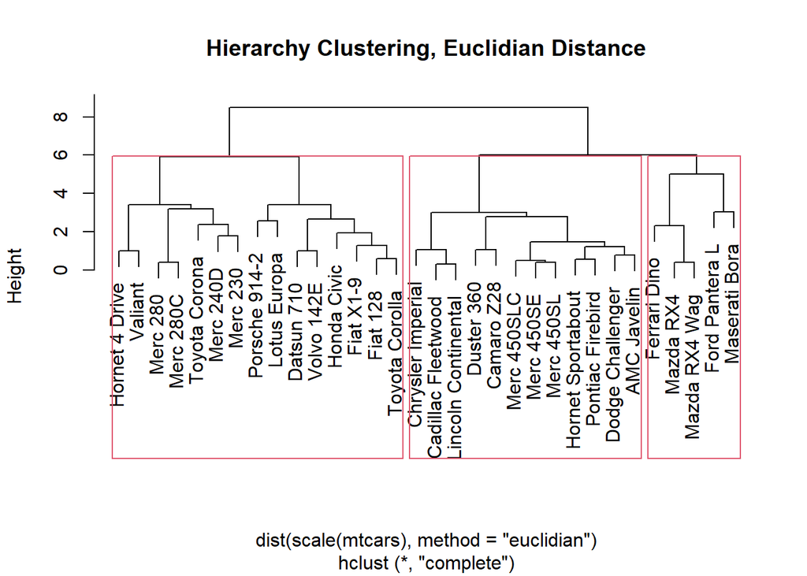

```r
plot(hclust(dist(scale(mtcars), method = 'euclidian')), main = 'Hierarchy Clustering, Euclidian Distance')
rect.hclust(hclust(dist(scale(mtcars), method = 'euclidian')), k = 3)
```

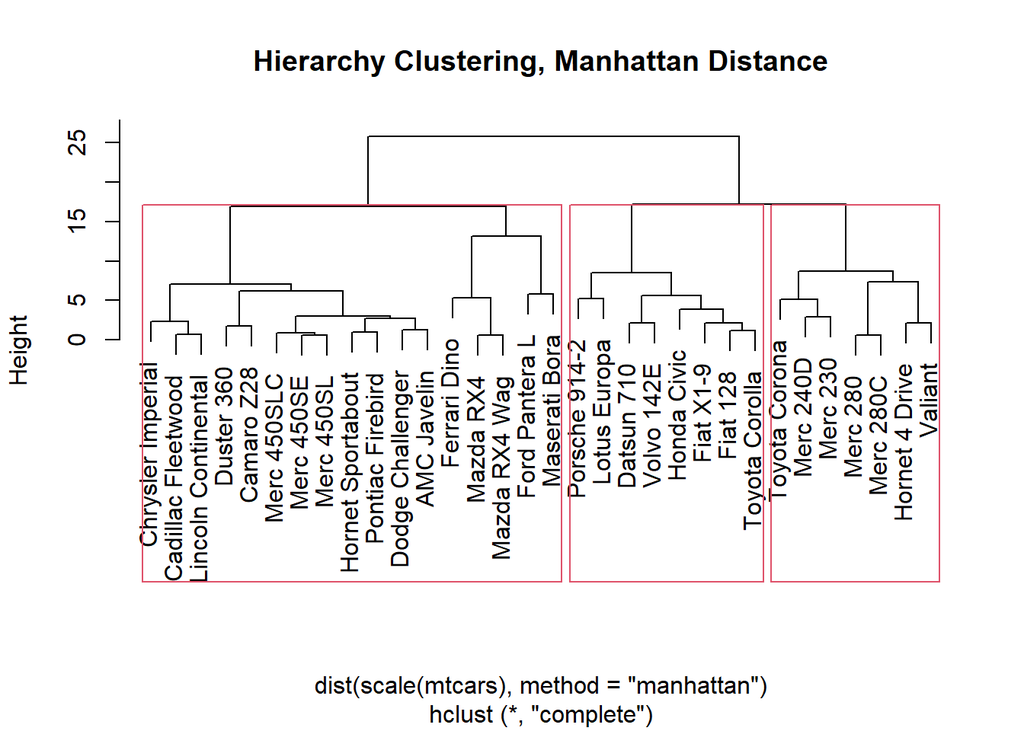

```r
plot(hclust(dist(scale(mtcars), method = 'manhattan')), main = 'Hierarchy Clustering, Manhattan Distance')
rect.hclust(hclust(dist(scale(mtcars), method = 'manhattan')), k = 3)
```

After scaling data, the two distance metrics offered seemingly different clusters. I added calls to *rect* to better visualize the differences. It appears that some of the clusters have similarities but there are discernible differences between the distance metrics.

```r
set.seed(1114)

train_index <- sample(seq_len(150), size =120) #generate random index separating iris into specified samples
train <- iris[train_index, -5] #training data
test <- iris[-train_index, -5] #test data

train_cat <- iris[train_index, 5]
test_cat <- iris[-train_index, 5]  #true designations for test

iris_predict <- (knn(train = train, test = test, cl = train_cat, k = 3)) #find predicted categories

table(iris_predict, test_cat) #contingency table
```

```
##             test_cat
## iris_predict setosa versicolor virginica
##   setosa          6          0         0
##   versicolor      0         13         0
##   virginica       0          1        10
```

Using kNN only missed a single categorization at k = 3.

**Ex. 5** – Use the *iris* dataset to carry out k-means clustering. Compare the results to the actual classes to estimate the clustering accuracy.

```r
set.seed(1114)

iris_kmeans <-  kmeans(iris[,-5], centers = 3)$cluster #obtain cluster designations

round(table(iris$Species, iris_kmeans)*100/150,1) #create contingency table for cluster numbers versus species
```

```
##             iris_kmeans
##                 1    2    3
##   setosa      0.0 33.3  0.0
##   versicolor  1.3  0.0 32.0
##   virginica  24.0  0.0  9.3
```

```r
set.seed(1114)

iris_kmeans <-  kmeans(iris[,-5], centers = 5)$cluster #obtain cluster designations

round(table(iris$Species, iris_kmeans)*100/150,1) #create contingency table for cluster numbers versus species
```

```
##             iris_kmeans
##                 1    2    3    4    5
##   setosa      0.0 14.7  0.0 18.7  0.0
##   versicolor 15.3  0.0 18.0  0.0  0.0
##   virginica  11.3  0.0  0.7  0.0 21.3
```

While the result is a little difficult ot understand, it still appears there are accuracy problems with k-means compared to knn.